# Starbucks Capstone Challenge

### Introduction

This data set contains simulated data that mimics customer behavior on the Starbucks rewards mobile app. Once every few days, Starbucks sends out an offer to users of the mobile app. An offer can be merely an advertisement for a drink or an actual offer such as a discount or BOGO (buy one get one free). Some users might not receive any offer during certain weeks.

Not all users receive the same offer, and that is the challenge to solve with this data set.

Your task is to combine transaction, demographic and offer data to determine which demographic groups respond best to which offer type. This data set is a simplified version of the real Starbucks app because the underlying simulator only has one product whereas Starbucks actually sells dozens of products.

Every offer has a validity period before the offer expires. As an example, a BOGO offer might be valid for only 5 days. You'll see in the data set that informational offers have a validity period even though these ads are merely providing information about a product; for example, if an informational offer has 7 days of validity, you can assume the customer is feeling the influence of the offer for 7 days after receiving the advertisement.

You'll be given transactional data showing user purchases made on the app including the timestamp of purchase and the amount of money spent on a purchase. This transactional data also has a record for each offer that a user receives as well as a record for when a user actually views the offer. There are also records for when a user completes an offer.

Keep in mind as well that someone using the app might make a purchase through the app without having received an offer or seen an offer.

### Example

To give an example, a user could receive a discount offer buy 10 dollars get 2 off on Monday. The offer is valid for 10 days from receipt. If the customer accumulates at least 10 dollars in purchases during the validity period, the customer completes the offer.

However, there are a few things to watch out for in this data set. Customers do not opt into the offers that they receive; in other words, a user can receive an offer, never actually view the offer, and still complete the offer. For example, a user might receive the "buy 10 dollars get 2 dollars off offer", but the user never opens the offer during the 10 day validity period. The customer spends 15 dollars during those ten days. There will be an offer completion record in the data set; however, the customer was not influenced by the offer because the customer never viewed the offer.

### Cleaning

This makes data cleaning especially important and tricky.

You'll also want to take into account that some demographic groups will make purchases even if they don't receive an offer. From a business perspective, if a customer is going to make a 10 dollar purchase without an offer anyway, you wouldn't want to send a buy 10 dollars get 2 dollars off offer. You'll want to try to assess what a certain demographic group will buy when not receiving any offers.

### Final Advice

Because this is a capstone project, you are free to analyze the data any way you see fit. For example, you could build a machine learning model that predicts how much someone will spend based on demographics and offer type. Or you could build a model that predicts whether or not someone will respond to an offer. Or, you don't need to build a machine learning model at all. You could develop a set of heuristics that determine what offer you should send to each customer (i.e., 75 percent of women customers who were 35 years old responded to offer A vs 40 percent from the same demographic to offer B, so send offer A).

# Data Sets

The data is contained in three files:

- portfolio.json - containing offer ids and meta data about each offer (duration, type, etc.)
- profile.json - demographic data for each customer
- transcript.json - records for transactions, offers received, offers viewed, and offers completed

Here is the schema and explanation of each variable in the files:

**portfolio.json**

- id (string) - offer id
- offer_type (string) - type of offer ie BOGO, discount, informational
- difficulty (int) - minimum required spend to complete an offer
- reward (int) - reward given for completing an offer
- duration (int) - time for offer to be open, in days
- channels (list of strings)

**profile.json**

- age (int) - age of the customer
- became_member_on (int) - date when customer created an app account
- gender (str) - gender of the customer (note some entries contain 'O' for other rather than M or F)
- id (str) - customer id
- income (float) - customer's income

**transcript.json**

- event (str) - record description (ie transaction, offer received, offer viewed, etc.)
- person (str) - customer id
- time (int) - time in hours since start of test. The data begins at time t=0
- value - (dict of strings) - either an offer id or transaction amount depending on the record

**Note:** If you are using the workspace, you will need to go to the terminal and run the command `conda update pandas` before reading in the files. This is because the version of pandas in the workspace cannot read in the transcript.json file correctly, but the newest version of pandas can. You can access the termnal from the orange icon in the top left of this notebook.

You can see how to access the terminal and how the install works using the two images below. First you need to access the terminal:

[figure not shown]

Then you will want to run the above command:

[figure not shown]

Finally, when you enter back into the notebook (use the jupyter icon again), you should be able to run the below cell without any errors.

# Question that will be answered:

### Which types of BOGO and Discount offers should be suggested for each client?

```python
import pandas as pd
import numpy as np
import json
import matplotlib.pyplot as plt
import seaborn as sns
import itertools

# read in the json files
portfolio = pd.read_json('data/portfolio.json', orient='records', lines=True)
profile = pd.read_json('data/profile.json', orient='records', lines=True)
transcript = pd.read_json('data/transcript.json', orient='records', lines=True)
```

# General Preprocess Data

In order to solve this problem we need to preprocess data before. The following steps will check for opportunities of preprocess data, such as removal of duplicates, fill Nan values, transform list values into columns and change type of columns.

### Preprocess Portfolio Dataset

Portfolio dataset has 10 rows, so it is not necessary checking duplicates.

```python
portfolio
```

|  | reward | channels | difficulty | duration | offer_type | id |
| --- | --- | --- | --- | --- | --- | --- |
| 0 | 10 | [email, mobile, social] | 10 | 7 | bogo | ae264e3637204a6fb9bb56bc8210ddfd |
| 1 | 10 | [web, email, mobile, social] | 10 | 5 | bogo | 4d5c57ea9a6940dd891ad53e9dbe8da0 |
| 2 | 0 | [web, email, mobile] | 0 | 4 | informational | 3f207df678b143eea3cee63160fa8bed |
| 3 | 5 | [web, email, mobile] | 5 | 7 | bogo | 9b98b8c7a33c4b65b9aebfe6a799e6d9 |
| 4 | 5 | [web, email] | 20 | 10 | discount | 0b1e1539f2cc45b7b9fa7c272da2e1d7 |
| 5 | 3 | [web, email, mobile, social] | 7 | 7 | discount | 2298d6c36e964ae4a3e7e9706d1fb8c2 |
| 6 | 2 | [web, email, mobile, social] | 10 | 10 | discount | fafdcd668e3743c1bb461111dcafc2a4 |
| 7 | 0 | [email, mobile, social] | 0 | 3 | informational | 5a8bc65990b245e5a138643cd4eb9837 |
| 8 | 5 | [web, email, mobile, social] | 5 | 5 | bogo | f19421c1d4aa40978ebb69ca19b0e20d |
| 9 | 2 | [web, email, mobile] | 10 | 7 | discount | 2906b810c7d4411798c6938adc9daaa5 |

### Preprocess Profile Dataset

Visualizing the first 5 rows of this dataset we can realize that there are Nan values. Lets change "became_member_on" column to datetime type and also calculate de time as a member of each person, maybe the time as member can influence the preferences of offers for users.

Lets also understand the representative of this Nan values and also format the date column and split into year and months.

```python
profile.head()
```

|  | gender | age | id | became_member_on | income |
| --- | --- | --- | --- | --- | --- |
| 0 | None | 118 | 68be06ca386d4c31939f3a4f0e3dd783 | 20170212 | NaN |
| 1 | F | 55 | 0610b486422d4921ae7d2bf64640c50b | 20170715 | 112000.0 |
| 2 | None | 118 | 38fe809add3b4fcf9315a9694bb96ff5 | 20180712 | NaN |
| 3 | F | 75 | 78afa995795e4d85b5d9ceeca43f5fef | 20170509 | 100000.0 |
| 4 | None | 118 | a03223e636434f42ac4c3df47e8bac43 | 20170804 | NaN |

```python
profile_process = profile.copy()

# Change became_member_on from int to datetime and split into columns the year, month and day
profile_process['became_member_on'] = pd.to_datetime(profile_process.became_member_on,format='%Y%m%d')

profile_process['time_as_member'] = profile_process.became_member_on.max()-profile_process['became_member_on']
profile_process['time_as_member'] = profile_process['time_as_member'].dt.days

profile_process.head()
```

|  | gender | age | id | became_member_on | income | time_as_member |
| --- | --- | --- | --- | --- | --- | --- |
| 0 | None | 118 | 68be06ca386d4c31939f3a4f0e3dd783 | 2017-02-12 | NaN | 529 |
| 1 | F | 55 | 0610b486422d4921ae7d2bf64640c50b | 2017-07-15 | 112000.0 | 376 |
| 2 | None | 118 | 38fe809add3b4fcf9315a9694bb96ff5 | 2018-07-12 | NaN | 14 |
| 3 | F | 75 | 78afa995795e4d85b5d9ceeca43f5fef | 2017-05-09 | 100000.0 | 443 |
| 4 | None | 118 | a03223e636434f42ac4c3df47e8bac43 | 2017-08-04 | NaN | 356 |

Checking for the quantity of nan value of each column we realize that just gender and income has it.

```python
profile_process.isna().sum()
```

```
gender              2175
age                    0
id                     0
became_member_on       0
income              2175
time_as_member         0
dtype: int64
```

Checking the indexes of each rows with Nan values for these columns we see that they are the same. Also the age is always filled with de 118 integer. So, the profile of those people we do not have detailed info will just be used to identify differences on how long the customer became a member.

```python
rows_nan_gender = profile_process.gender[profile_process.gender.isna()].index
rows_nan_income = profile_process.income[profile_process.income.isna()].index
rows_118_age = profile_process.age[profile_process.age==118].index

equal_nan_income_gender = (rows_nan_income==rows_nan_gender).sum()
equal_nan_income_age = (rows_nan_income==rows_118_age).sum()

if (equal_nan_income_gender == 2175):
    print('The rows of Nan values of income and gender are the same')
else:
    print('There are {} rows which have Nan values and are different from income and gender'
          .format(2175 - equal_nan_income_gender))

if (equal_nan_income_age == 2175):
    print('The rows of Nan values of income and gender are the same')
else:
    print('There are {} rows which have Nan values and are different from income and age 118'
          .format(2175 - equal_nan_income_age))
```

```
The rows of Nan values of income and gender are the same
The rows of Nan values of income and gender are the same
```

### Preprocess Transcript Dataset

Looking at the data set we realize "value" column data colud be better used if splitted in 2 other ones: value_type and value_offer.

```python
transcript.head()
```

|  | person | event | value | time |
| --- | --- | --- | --- | --- |
| 0 | 78afa995795e4d85b5d9ceeca43f5fef | offer received | {'offer id': '9b98b8c7a33c4b65b9aebfe6a799e6d9'} | 0 |
| 1 | a03223e636434f42ac4c3df47e8bac43 | offer received | {'offer id': '0b1e1539f2cc45b7b9fa7c272da2e1d7'} | 0 |
| 2 | e2127556f4f64592b11af22de27a7932 | offer received | {'offer id': '2906b810c7d4411798c6938adc9daaa5'} | 0 |
| 3 | 8ec6ce2a7e7949b1bf142def7d0e0586 | offer received | {'offer id': 'fafdcd668e3743c1bb461111dcafc2a4'} | 0 |
| 4 | 68617ca6246f4fbc85e91a2a49552598 | offer received | {'offer id': '4d5c57ea9a6940dd891ad53e9dbe8da0'} | 0 |

As we can see below, there are 2 different ways that offer id was registered. Lets pass all these valor to "offer id".

```python
# Preprocess transcript value
transcript_process = transcript.copy()

# Splitting value into value_type and value_offer and drop value column
transcript_process['value_type'] = transcript_process.value.apply(lambda x: list(x.keys())[0])
transcript_process['value_offer'] = transcript_process.value.apply(lambda x: x[list(x.keys())[0]])
transcript_process = transcript_process.drop('value',axis=1)

transcript_process.value_type.value_counts()
```

```
amount      138953
offer id    134002
offer_id     33579
Name: value_type, dtype: int64
```

```python
# Unify offer ids
transcript_process['value_type'] = transcript_process.value_type.apply(lambda x: 'offer id' if (x=='offer_id') else x)
transcript_process.value_type.value_counts()
```

```
offer id    167581
amount      138953
Name: value_type, dtype: int64
```

```python
# Split amount and offer id value into 2 different columns. If not a transaction amount_value is 0
transcript_process = pd.concat([transcript_process,transcript_process.pivot(columns='value_type',values='value_offer')],axis=1)
transcript_process = transcript_process.drop('value_offer',axis=1)
transcript_process = transcript_process.rename(columns={'amount':'amount_value','offer id':'offer_id_value'})
transcript_process['amount_value'] = transcript_process.amount_value.fillna(0)
transcript_process.head()
```

|  | person | event | time | value_type | amount_value | offer_id_value |
| --- | --- | --- | --- | --- | --- | --- |
| 0 | 78afa995795e4d85b5d9ceeca43f5fef | offer received | 0 | offer id | 0.0 | 9b98b8c7a33c4b65b9aebfe6a799e6d9 |
| 1 | a03223e636434f42ac4c3df47e8bac43 | offer received | 0 | offer id | 0.0 | 0b1e1539f2cc45b7b9fa7c272da2e1d7 |
| 2 | e2127556f4f64592b11af22de27a7932 | offer received | 0 | offer id | 0.0 | 2906b810c7d4411798c6938adc9daaa5 |
| 3 | 8ec6ce2a7e7949b1bf142def7d0e0586 | offer received | 0 | offer id | 0.0 | fafdcd668e3743c1bb461111dcafc2a4 |
| 4 | 68617ca6246f4fbc85e91a2a49552598 | offer received | 0 | offer id | 0.0 | 4d5c57ea9a6940dd891ad53e9dbe8da0 |

```python
total_offers = len(transcript_process)
offers_no_duplicated = len(transcript_process.drop_duplicates())

print('There were {} rows duplicates in transcripts database'.format(total_offers-offers_no_duplicated))

transcript_process = transcript_process.drop_duplicates()
```

```
There were 397 rows duplicates in transcripts database
```

```python
# Order transactions by person and offer_id_values to identify which row refers to the same offer
no_transactions = transcript_process[transcript_process['event']!='transaction']
no_transactions = no_transactions.sort_values(['person','offer_id_value'])
#no_transactions['key'] = no_transactions['person']+no_transactions['offer_id_value']

values = []
last_key = 0
unique = 0
for index, row in no_transactions[['event']].iterrows():
    if (row[0]=='offer received'):
        unique = unique+1
    values.append([unique])

unique_value_offer = pd.DataFrame(values,columns=['unique value offer'])
no_transactions = pd.concat([no_transactions.reset_index(),unique_value_offer],axis=1)
no_transactions.head()
```

|  | index | person | event | time | value_type | amount_value | offer_id_value | unique value offer |
| --- | --- | --- | --- | --- | --- | --- | --- | --- |
| 0 | 247879 | 0009655768c64bdeb2e877511632db8f | offer received | 576 | offer id | 0.0 | 2906b810c7d4411798c6938adc9daaa5 | 1 |
| 1 | 258884 | 0009655768c64bdeb2e877511632db8f | offer completed | 576 | offer id | 0.0 | 2906b810c7d4411798c6938adc9daaa5 | 1 |
| 2 | 113605 | 0009655768c64bdeb2e877511632db8f | offer received | 336 | offer id | 0.0 | 3f207df678b143eea3cee63160fa8bed | 2 |
| 3 | 139992 | 0009655768c64bdeb2e877511632db8f | offer viewed | 372 | offer id | 0.0 | 3f207df678b143eea3cee63160fa8bed | 2 |
| 4 | 55972 | 0009655768c64bdeb2e877511632db8f | offer received | 168 | offer id | 0.0 | 5a8bc65990b245e5a138643cd4eb9837 | 3 |

# Data Visualization

After preprocessing the databases and merging them, let's identify insights.

### Profile Insights

1. There are big differences in time as member?
   - There are 3 waves in the time as member histogram below. Indicating there were moments of big number of new members.
2. There is a difference of number of male, female?
   - Yes, there are ~38% more men than women as members
3. There is a differente in distribution of age and income by gender?
   - Difference between the mean and median of ages and income are really low, indicating groups based on gender has a really similar distribuition: Mean age: 54.4. Median Age 55.0 Mean income: 65405.0. Media income 64000.0

```
Mean days as member: 517.4. Median days as member: 358.0
```

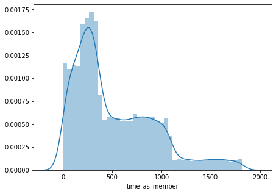

```python
time_as_member = profile_process.copy()
time_as_member['today'] = profile_process.became_member_on.max()
time_as_member['time_as_member'] = time_as_member['today']-time_as_member['became_member_on']
time_as_member['time_as_member'] = time_as_member['time_as_member'].dt.days

print('Mean days as member: {}. Median days as member: {}'.format(np.round(time_as_member['time_as_member'].mean(),1),
                                           np.round(time_as_member['time_as_member'].median(),2)))

# Plot data about days as members
fig, ax1 = plt.subplots(1,1,figsize=(7,5))
sns.distplot(time_as_member['time_as_member'],ax=ax1)
plt.show()
```

```
There are 38.42 % more men members than women
```

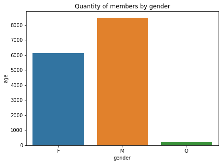

```python
# Remove rows with ages equal 118
members_gender_age = profile_process[profile_process.age!=118][['gender','age']]

# Count merbers by gender
count_men_women = members_gender_age.groupby('gender').count()
men_count = count_men_women.loc['M'][0]
women_count = count_men_women.loc['F'][0]

print('There are {} % more men members than women'.format(np.round((men_count/women_count-1)*100,2)))

# Plot data about number of members by age and gender
fig, ax1 = plt.subplots(1,1,figsize=(7,5))
sns.barplot(x=count_men_women.index,y=count_men_women.age,ax=ax1)
ax1.set_title('Quantity of members by gender')
plt.show()
```

```
Mean age: 54.4. Median Age 55.0
Mean income: 65405.0. Media income 64000.0
```

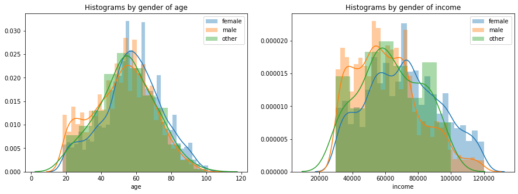

```python
# filter ages by gender
men_members_age = members_gender_age.loc[members_gender_age['gender']=='M']['age']
fem_members_age = members_gender_age.loc[members_gender_age['gender']=='F']['age']
other_members_age = members_gender_age.loc[members_gender_age['gender']=='O']['age']

members_gender_income = profile_process[['gender','income']]

# filter ages by gender
men_members_income = members_gender_income.loc[members_gender_income['gender']=='M']['income']
fem_members_income = members_gender_income.loc[members_gender_income['gender']=='F']['income']
other_members_income = members_gender_income.loc[members_gender_income['gender']=='O']['income']

print('Mean age: {}. Median Age {}'.format(np.round(members_gender_age.mean()[0],1),
                                           np.round(members_gender_age.median()[0],2)))

# Plot data about number of members by age and gender
fig, [ax1,ax2] = plt.subplots(1,2,figsize=(15,5))
sns.distplot(fem_members_age,ax=ax1,label='female')
sns.distplot(men_members_age,ax=ax1,label='male')
sns.distplot(other_members_age,ax=ax1,label='other')
ax1.set_title('Histograms by gender of age')
ax1.legend()

print('Mean income: {}. Media income {}'.format(np.round(members_gender_income.mean()[0],1),
                                                np.round(members_gender_income.median()[0],2)))

sns.distplot(fem_members_income,ax=ax2,label='female')
sns.distplot(men_members_income,ax=ax2,label='male')
sns.distplot(other_members_income,ax=ax2,label='other')
ax2.set_title('Histograms by gender of income')
ax2.legend()
plt.show()
```

### Transcript Insights

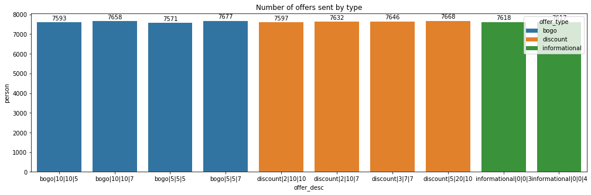

```python
# Finding quantity of offers received by type
offers = transcript_process.merge(portfolio,left_on='offer_id_value',right_on='id')
offers['offer_desc'] = offers['offer_type']+"|"+offers['reward'].astype(str)+"|"+offers['difficulty'].astype(str)+"|"+offers['duration'].astype(str)
offers_sent = offers[offers['event']=='offer received']
offers_sent = offers_sent.groupby(['offer_type','offer_desc']).count()[['person']].reset_index()

# Plotting results
fig,ax = plt.subplots(1,1,figsize=(17,5))
chart = sns.barplot(x='offer_desc',y='person',hue='offer_type',data=offers_sent,dodge=False,ax=ax)
for p in chart.patches:
    chart.annotate(format(p.get_height(), '.0f'),
                       (p.get_x() + p.get_width() / 2., p.get_height()),
                       ha = 'center', va = 'center',
                       xytext = (0, 7),
                       textcoords = 'offset points')

ax.set_title('Number of offers sent by type')
plt.show()
```

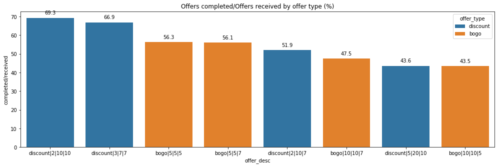

```python
# Finding the tax of offers completed over offers received by offer type
offers_no_trans = offers[offers['offer_type']!='transaction']
offers_no_trans = offers_no_trans.groupby(['offer_desc','event','offer_type']).count()['person'].reset_index()
offers_no_trans = offers_no_trans.pivot_table(columns=['event'],values=['person'],index=['offer_desc','offer_type'])['person']
offers_no_trans['views/received'] = offers_no_trans['offer viewed']/offers_no_trans['offer received']*100
offers_no_trans['completed/received'] = offers_no_trans['offer completed']/offers_no_trans['offer received']*100
offers_no_trans = offers_no_trans.sort_values('completed/received',ascending=False).dropna().reset_index()

# Plotting results
fig,ax = plt.subplots(1,1,figsize=(17,5))
chart = sns.barplot(x='offer_desc',y='completed/received',hue='offer_type',data=offers_no_trans,dodge=False,ax=ax)
for p in chart.patches:
    chart.annotate(format(p.get_height(), '.1f'),
                   (p.get_x() + p.get_width() / 2., p.get_height()),
                   ha = 'center', va = 'center',
                   xytext = (0, 10),
                   textcoords = 'offset points')
ax.set_title('Offers completed/Offers received by offer type (%)')
plt.show()
```

# Steps to answer the question

After discovering more about the datasets and distributions, the following steps should be executed in order to find the best offer for each person:

**1) Preprocessing data**

```
- Define offers completed paying attention to:
    - Offers completed before viewed
    - Offers completed after end of offer
- generate database with groups of age, gender, income, time as member and offers completed/total offers
- Identify people which should not receive BOGO or discount offers, in other words, those people which completes all offers after viewing the offer, which did not see them or even completed after offer time limit.
```

**2) Defining groups**

```
- Identify which variables (age, gender, income, time as member) should be used to cluster.
    - How: Choosing variables that has impact in offers completed/total offers (BOGO and discounts) and are not highly correlated
- Preprocess variables and cluster people
```

**3) Ranking offers by group**

```
- Rank each group and type of offer based on offers completed/total offers
```

```python
events = no_transactions.copy()
events = events.merge(portfolio,left_on='offer_id_value',right_on='id').drop('id',axis=1)
events['channels'] = events.channels.apply(lambda x: str(x))
events = events.merge(profile_process,left_on='person',right_on='id').drop('id',axis=1)

# Transform each row in an offer, with the respective time for receiving, viewing and completing
events_pivot = pd.pivot_table(events,columns='event',values='time',index=['person', 'value_type', 'amount_value',
       'offer_id_value', 'unique value offer', 'reward', 'channels',
       'difficulty', 'duration', 'offer_type', 'gender', 'age',
       'became_member_on', 'income', 'time_as_member'])

# Create variables of time to complete and max time to complete. Replance nan for 0 and dropping columns
events_pivot['time_to_view'] = events_pivot['offer viewed']-events_pivot['offer received']
events_pivot['time_to_complete'] = events_pivot['offer completed']-events_pivot['offer received']

#events_pivot_process = events_pivot.reset_index().drop(['offer completed','offer received','offer viewed'],axis=1)
events_pivot_process = events_pivot.reset_index()
events_pivot_process['max_time_complete'] = events_pivot_process.duration*24

# Helps to identify when person view some offer after completing
events_pivot_process['check_complete_moment'] = events_pivot_process['time_to_complete'] - events_pivot_process['time_to_view']
# Helps to identify when person complete offer after time limit
events_pivot_process['check_max_time'] = events_pivot_process['time_to_complete'] - events_pivot_process['max_time_complete']

events_pivot_process['check_complete_moment'] = events_pivot_process['check_complete_moment'].fillna(-1)
events_pivot_process['check_max_time'] = events_pivot_process['check_max_time'].fillna(1)

events_pivot_process['worked_01'] = events_pivot_process['check_complete_moment'].apply(lambda x: 1 if (x<=0) else 0)
events_pivot_process['worked_02'] = events_pivot_process['check_max_time'].apply(lambda x: 1 if (x>=0) else 0)
events_pivot_process['worked'] = events_pivot_process['worked_01']+events_pivot_process['worked_02']

# Check the number of offers completes that worked (0).
# Indicating offers not completed, completed before viewing or not event seen (worked_01 = 1) and after offer time limit or not completed (worked_02=1).
# 0 - Offer worked, 1 or 2 - Offer did not work
events_pivot_process.worked.value_counts()
```

```
2    34590
0    19411
1    12500
Name: worked, dtype: int64
```

```python
# Remove informational offers becasu the metric of success is the number of transactions and amount, instead of offers completed/offers received
events_no_info = events_pivot_process[events_pivot_process.offer_type!='informational']
events_no_info.worked.value_counts()
```

```
2    21290
0    19411
1    12500
Name: worked, dtype: int64
```

Below we find people who received offers of discounts and BOGO but never completed one correctly, in other words, after viewing the offer and after time limit. We notice even that there are people which has received more offers than the median. It indicates that part of them received the same opportunity to complete an offer.

Considering this fact the recommendation for these people is not receive offers any more

```
There are 1639 people that never completed an offer of discount or BOGO
The mean number of offers received by person is 4.0
```

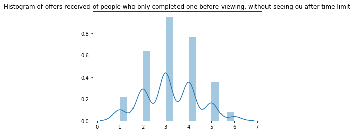

```python
# Person who completed at least one offer before viewing, without seeing or after time limit
person_not_worked = events_no_info[(events_no_info['worked']==1)]
person_not_worked = person_not_worked.person.drop_duplicates()

# Person who completed at least one offer correctly
person_worked = events_no_info[(events_no_info['worked']==0)]
person_worked = person_worked.person.drop_duplicates()

# People list that completed offers but not because of the effect of the offer
not_worked_list = person_not_worked[person_not_worked.isin(person_worked)==False]
offers_not_worked = events_no_info[events_no_info.person.isin(not_worked_list)==True].groupby('person').count()[['value_type']]
mean_offers = events_no_info.groupby('person').count()[['value_type']].median()

print('There are {} people that never completed an offer of discount or BOGO'.format(len(not_worked_list)))
print('The mean number of offers received by person is {}'.format(mean_offers[0]))
sns.distplot(offers_not_worked)
plt.title('Histogram of offers received of people who only completed one before viewing, without seeing ou after time limit')
plt.show()
```

```python
main_results = events_no_info.groupby(['person','age','income','gender','time_as_member','reward','difficulty','duration','offer_type','worked']).count()
main_results = main_results['value_type'].reset_index()
main_results = pd.pivot_table(main_results,columns=['worked'],values=['value_type'],index=['person','income','gender','age','time_as_member','reward','difficulty','duration','offer_type'])
main_results = main_results.fillna(0)

# Create columns to indicate if offer worked or not
main_results['not worked'] = main_results.value_type[1]+main_results.value_type[2]
main_results['worked'] = main_results.value_type[0]

main_results = main_results.drop('value_type',axis=1)
main_results.reset_index().head()
```

| worked | person | income | gender | age | time_as_member | reward | difficulty | duration | offer_type | not worked | worked |
| --- | --- | --- | --- | --- | --- | --- | --- | --- | --- | --- | --- |
| 0 | 0009655768c64bdeb2e877511632db8f | 72000.0 | M | 33 | 461 | 2 | 10 | 7 | discount | 1.0 | 0.0 |
| 1 | 0009655768c64bdeb2e877511632db8f | 72000.0 | M | 33 | 461 | 2 | 10 | 10 | discount | 1.0 | 0.0 |
| 2 | 0009655768c64bdeb2e877511632db8f | 72000.0 | M | 33 | 461 | 5 | 5 | 5 | bogo | 1.0 | 0.0 |
| 3 | 0011e0d4e6b944f998e987f904e8c1e5 | 57000.0 | O | 40 | 198 | 3 | 7 | 7 | discount | 0.0 | 1.0 |
| 4 | 0011e0d4e6b944f998e987f904e8c1e5 | 57000.0 | O | 40 | 198 | 5 | 5 | 7 | bogo | 0.0 | 1.0 |

We can conclude from the table below and the charts that the variables age, income and time_as_member statistically have an impact in the result (offers completed/offers received). Lets check if they have correlation between each other.

|  | variable | correlation | p-value |
| --- | --- | --- | --- |
| 0 | income | 0.684038 | 7.799804e-14 |
| 1 | age | 0.659585 | 8.918384e-12 |
| 2 | time_as_member | 0.156951 | 7.200104e-11 |

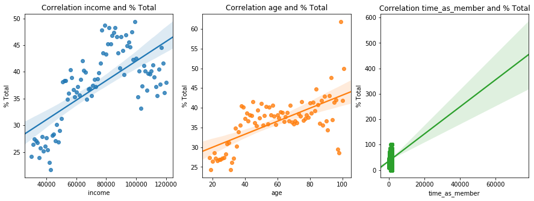

```python
from scipy import stats

pandas = []
fig, ax = plt.subplots(1,3,figsize=(15,5))
var_group = ['income','age','time_as_member']

for v, var in enumerate(var_group):
    var_grouped = main_results.groupby(var).sum().reset_index()
    var_grouped['% Total'] = var_grouped['worked']/(var_grouped['worked']+var_grouped['not worked'])*100
    corr, pvalue = stats.pearsonr(var_grouped[var],var_grouped['% Total'])
    sns.regplot(x=var_grouped[var],y=var_grouped['% Total'],ax=ax[v])
    ax[v].set_title('Correlation '+var+' and % Total')
    pandas.append([var, corr, pvalue])

pd.DataFrame(pandas,columns=['variable','correlation','p-value'])
```

As we can see age and income have a correlation of 0,307. Since the correlation is not big, higher than 0,5, we will keep all variables in the clustering process.

```python
main_results.reset_index()[['age','income','time_as_member']].corr()
```

|  | worked | age | income | time_as_member |
| --- | --- | --- | --- | --- |
| age |  | 1.000000 | 0.307404 | 0.007494 |
| income |  | 0.307404 | 1.000000 | 0.022364 |
| time_as_member |  | 0.007494 | 0.022364 | 1.000000 |

```python
from sklearn.preprocessing import StandardScaler
from sklearn.decomposition import PCA

cluster_data = main_results.reset_index()
cluster_data = cluster_data[cluster_data['person'].isin(not_worked_list)==False]
cluster_data = cluster_data[cluster_data['age']!=118][['age','gender','income','time_as_member']]
cluster_data = cluster_data.drop_duplicates()
cluster_data = cluster_data.dropna()

gender_map = {'M':0,'F':1,'O':2}
cluster_data = cluster_data.reset_index().drop('index',axis=1)
cluster_data['gender'] = cluster_data['gender'].map(gender_map)

scaler = StandardScaler()
standard_vars = scaler.fit_transform(cluster_data[['income','age','time_as_member']])

cluster_data = cluster_data.drop(['income','age','time_as_member'],axis=1)
standard_vars = pd.DataFrame(standard_vars,columns=['income','age','time_as_member'])

cluster_data = pd.concat([cluster_data,standard_vars],axis=1)
cluster_data.columns = ['gender','income','age','time_as_member']
cluster_data.head()
```

|  | gender | income | age | time_as_member |
| --- | --- | --- | --- | --- |
| 0 | 2 | -0.377615 | -0.816063 | -0.776726 |
| 1 | 1 | 1.158211 | 0.273760 | 0.828590 |
| 2 | 1 | -0.237995 | -1.733808 | 0.230159 |
| 3 | 1 | 0.367028 | -1.619090 | -0.297031 |
| 4 | 1 | -0.005294 | -2.020603 | 0.453383 |

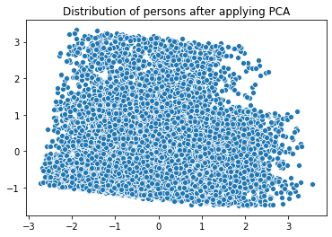

```python
pca = PCA(n_components=2)
dimensions = pca.fit_transform(cluster_data)
dimensions = np.array_split(dimensions,2,axis=1)
dim_0 = dimensions[0].flatten()
dim_1 = dimensions[1].flatten()
sns.scatterplot(x=dim_0,y=dim_1)
plt.title('Distribution of persons after applying PCA')
plt.show()
```

```python
# Ranges of ages applyied to data
bins_age = pd.IntervalIndex.from_tuples([(17, 25),(25,30),(30, 40),(40, 50),(50, 60),(60, 70),(70, 80),(80,120)])

cluster_data_grouped = main_results.reset_index().copy()
cluster_data_grouped['group_age'] = pd.cut(cluster_data_grouped['age'],bins_age).astype(str)
cluster_data_grouped['group_income'] = pd.cut(cluster_data_grouped['income'],3).astype(str)
cluster_data_grouped['group_time_as_member'] = pd.cut(cluster_data_grouped['time_as_member'],3).astype(str)

cluster_data_grouped = cluster_data_grouped.groupby(['group_age','group_income','group_time_as_member',
                                                        'gender','reward','difficulty','duration',
                                                        'offer_type']).sum()[['worked','not worked']].dropna(how='all')

# Calculates the main metric: offers completed/offers received
cluster_data_grouped['total'] = cluster_data_grouped['worked']+cluster_data_grouped['not worked']
cluster_data_grouped['% total'] = np.round(cluster_data_grouped['worked']/cluster_data_grouped['total']*100,2)
cluster_data_grouped = cluster_data_grouped.reset_index()
cluster_data_grouped.head()
```

| worked | group_age | group_income | group_time_as_member | gender | reward | difficulty | duration | offer_type | worked | not worked | total | % total |
| --- | --- | --- | --- | --- | --- | --- | --- | --- | --- | --- | --- | --- |
| 0 | (17, 25] | (29910.0, 60000.0] | (-1.823, 607.667] | F | 2 | 10 | 7 | discount | 13.0 | 43.0 | 56.0 | 23.21 |
| 1 | (17, 25] | (29910.0, 60000.0] | (-1.823, 607.667] | F | 2 | 10 | 10 | discount | 17.0 | 27.0 | 44.0 | 38.64 |
| 2 | (17, 25] | (29910.0, 60000.0] | (-1.823, 607.667] | F | 3 | 7 | 7 | discount | 26.0 | 35.0 | 61.0 | 42.62 |
| 3 | (17, 25] | (29910.0, 60000.0] | (-1.823, 607.667] | F | 5 | 5 | 5 | bogo | 22.0 | 41.0 | 63.0 | 34.92 |
| 4 | (17, 25] | (29910.0, 60000.0] | (-1.823, 607.667] | F | 5 | 5 | 7 | bogo | 8.0 | 37.0 | 45.0 | 17.78 |

```python
# For each cluster, filter the offers with highest result (% total)
clusters = cluster_data_grouped[['group_age','group_income','group_time_as_member','gender']].drop_duplicates()
ranking = []
for c in clusters.iterrows():
    cluster_filter = cluster_data_grouped[(cluster_data_grouped['group_age']==c[1][0]) &
                        (cluster_data_grouped['group_income']==c[1][1]) &
                        (cluster_data_grouped['group_time_as_member']==c[1][2] )&
                       (cluster_data_grouped['gender']==c[1][3])]
    cluster_filter = cluster_filter.sort_values('% total',ascending=False)
    ranking.append(cluster_filter.iloc[0])
ranking = pd.DataFrame(ranking).sort_values('total',ascending=False)
ranking.head()
```

| worked | group_age | group_income | group_time_as_member | gender | reward | difficulty | duration | offer_type | worked | not worked | total | % total |
| --- | --- | --- | --- | --- | --- | --- | --- | --- | --- | --- | --- | --- |
| 767 | (60, 70] | (29910.0, 60000.0] | (-1.823, 607.667] | M | 2 | 10 | 10 | discount | 94.0 | 144.0 | 238.0 | 39.50 |
| 571 | (50, 60] | (29910.0, 60000.0] | (-1.823, 607.667] | M | 2 | 10 | 10 | discount | 105.0 | 132.0 | 237.0 | 44.30 |
| 639 | (50, 60] | (60000.0, 90000.0] | (-1.823, 607.667] | M | 2 | 10 | 10 | discount | 125.0 | 96.0 | 221.0 | 56.56 |
| 389 | (40, 50] | (29910.0, 60000.0] | (-1.823, 607.667] | M | 3 | 7 | 7 | discount | 101.0 | 120.0 | 221.0 | 45.70 |
| 223 | (30, 40] | (29910.0, 60000.0] | (-1.823, 607.667] | M | 2 | 10 | 10 | discount | 99.0 | 118.0 | 217.0 | 45.62 |

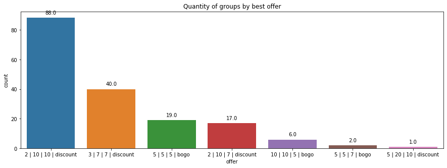

```python
# Counts the number of groups each offer is the best for being recommended
ranking_grouped = ranking.groupby(['reward','difficulty','duration','offer_type']).count()[['group_age']]
ranking_grouped = ranking_grouped.reset_index()
ranking_grouped = ranking_grouped.rename(columns={'group_age':'count'})
ranking_grouped['offer'] = ranking_grouped.reward.astype(str)+" | "+ranking_grouped.difficulty.astype(str)+" | "+ranking_grouped.duration.astype(str)+" | "+ranking_grouped.offer_type.astype(str)
ranking_grouped = ranking_grouped.sort_values('count',ascending=False)

fig,ax = plt.subplots(1,1,figsize=(15,5))
chart = sns.barplot(x='offer',y='count',data=ranking_grouped,ax=ax)
for p in chart.patches:
    chart.annotate(format(p.get_height(), '.1f'),
                   (p.get_x() + p.get_width() / 2., p.get_height()),
                   ha = 'center', va = 'center',
                   xytext = (0, 10),
                   textcoords = 'offset points')
plt.title('Quantity of groups by best offer')
plt.show()
```